# Credit Card Fraud Detection Techiques (Classification Approach)

## Step 1: Importing the Packages

```python
#Implementation of Packages
import numpy as np
import pandas as pd
import matplotlib.pyplot as plt
import seaborn as sns

from sklearn.preprocessing import StandardScaler
from sklearn.model_selection import train_test_split
from sklearn.linear_model import LogisticRegression
from sklearn.tree import DecisionTreeClassifier
from sklearn.ensemble import RandomForestClassifier
from sklearn.svm import SVC
from sklearn.neighbors import KNeighborsClassifier
```

# Step 2: Exploratory Data Analysis

The credit card fraud dataset has been obtained from a public repository Kaggle. It is comprised of a plethora of economic parameters of different credit card account holders.The columns "foreign_worker" , "other_parties", and"other payment plans" will be removed because they do not provide enough info to cause alert to a fraudulent or legitimate credit card account due to lack of variability. The classification aim is to predit whether an account is fraudulent or legitimate based on the information provided.

```python
#Importing Data
data = pd.read_csv(r"C:\Users\Misty\OneDrive\Documents\Credit Card Fraud.csv")
data.drop('foreign_worker', axis = 1, inplace = True)
data.drop('other_parties', axis = 1, inplace = True )
data.drop('other_payment_plans', axis = 1, inplace = True)
data.head()
```

|  | over_draft | credit_usage | credit_history | purpose | current_balance | Average_Credit_Balance | employment | location | personal_status | residence_since | property_magnitude | cc_age | housing | existing_credits | job | num_dependents | own_telephone | class |
| --- | --- | --- | --- | --- | --- | --- | --- | --- | --- | --- | --- | --- | --- | --- | --- | --- | --- | --- |
| 0 | <0 | 6 | critical/other existing credit | radio/tv | 1169 | no known savings | >=7 | 4 | male single | 4 | real estate | 67 | own | 2 | skilled | 1 | yes | good |
| 1 | 0<=X<200 | 48 | existing paid | radio/tv | 5951 | <100 | 1<=X<4 | 2 | female div/dep/mar | 2 | real estate | 22 | own | 1 | skilled | 1 | none | bad |
| 2 | no checking | 12 | critical/other existing credit | education | 2096 | <100 | 4<=X<7 | 2 | male single | 3 | real estate | 49 | own | 1 | unskilled resident | 2 | none | good |
| 3 | <0 | 42 | existing paid | furniture/equipment | 7882 | <100 | 4<=X<7 | 2 | male single | 4 | life insurance | 45 | for free | 1 | skilled | 2 | none | good |
| 4 | <0 | 24 | delayed previously | new car | 4870 | <100 | 1<=X<4 | 3 | male single | 4 | no known property | 53 | for free | 2 | skilled | 2 | none | bad |

```python
#copy of our dataset
df=data.copy()
```

```python
#Shape of the data after removing columns and rows
print("Rows    :",data.shape[0])
print("Columns :",data.shape[1])
```

```
Rows    : 1000
Columns : 18
```

```python
# how many columns in the dataset
data.columns
#check for any NULL values in the dataset
data.info()
```

```
<class 'pandas.core.frame.DataFrame'>
RangeIndex: 1000 entries, 0 to 999
Data columns (total 18 columns):
 #   Column                  Non-Null Count  Dtype
---  ------                  --------------  -----
 0   over_draft              1000 non-null   object
 1   credit_usage            1000 non-null   int64
 2   credit_history          1000 non-null   object
 3   purpose                 1000 non-null   object
 4   current_balance         1000 non-null   int64
 5   Average_Credit_Balance  1000 non-null   object
 6   employment              1000 non-null   object
 7   location                1000 non-null   int64
 8   personal_status         1000 non-null   object
 9   residence_since         1000 non-null   int64
 10  property_magnitude      1000 non-null   object
 11  cc_age                  1000 non-null   int64
 12  housing                 1000 non-null   object
 13  existing_credits        1000 non-null   int64
 14  job                     1000 non-null   object
 15  num_dependents          1000 non-null   int64
 16  own_telephone           1000 non-null   object
 17  class                   1000 non-null   object
dtypes: int64(7), object(11)
memory usage: 140.8+ KB
```

Having null or missing values can lead to wrong predictions and bias, fortunately there are no missing values within our dataset that need to be removed.

```python
#The categorical variables in our dataset
for col in df.select_dtypes("object"):
    print(col)
```

```
over_draft
credit_history
purpose
Average_Credit_Balance
employment
personal_status
property_magnitude
housing
job
own_telephone
class
```

```python
#The numeric variables dataset
for col in df.select_dtypes("int64"):
    print(col)
```

```
credit_usage
current_balance
location
residence_since
cc_age
existing_credits
num_dependents
```

Below I will take a look at the target variable 'class' and its distribution within our dataset. 'Class'-good -account is legitimate bad'-account is fraudulent

```python
df['class'].value_counts()
```

```
good    700
bad     300
Name: class, dtype: int64
```

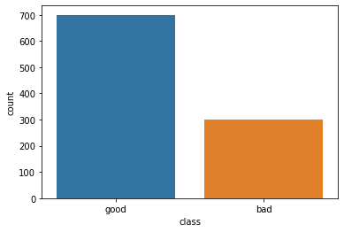

```python
sns.countplot(x='class', data=df)
```

The target variable is very imbalanced with 700 good(legitimate) cases and 300 bad(fraud), further data exploration a few of the other categorical variables will be conducted before I balance the classes.

```python
#The means of the target variable 'class'
df.groupby('class').mean()
```

| class | credit_usage | current_balance | location | residence_since | cc_age | existing_credits | num_dependents |
| --- | --- | --- | --- | --- | --- | --- | --- |
| bad | 24.860000 | 3938.126667 | 3.096667 | 2.850000 | 33.963333 | 1.366667 | 1.153333 |
| good | 19.207143 | 2985.457143 | 2.920000 | 2.842857 | 36.224286 | 1.424286 | 1.155714 |

Observations:

```
- Current balance as well as use of credit of accounts is a lot higher for the fraudulent accounts versus the legitimate
-older accounts (cc_age) are more likely to be legitamate opposed to new accounts.
```

Lets calculate the means of our categorical variables for further data exploration.

```python
df.groupby('over_draft').mean()
```

| over_draft | credit_usage | current_balance | location | residence_since | cc_age | existing_credits | num_dependents |
| --- | --- | --- | --- | --- | --- | --- | --- |
| 0<=X<200 | 22.680297 | 3827.561338 | 2.877323 | 2.743494 | 34.081784 | 1.356877 | 1.115242 |
| <0 | 21.339416 | 3175.218978 | 3.058394 | 3.003650 | 35.339416 | 1.379562 | 1.189781 |
| >=200 | 17.349206 | 2177.650794 | 2.793651 | 2.571429 | 37.190476 | 1.317460 | 1.142857 |
| no checking | 19.954315 | 3133.101523 | 3.007614 | 2.847716 | 36.426396 | 1.474619 | 1.159898 |

Observations: If credit usage is low account is most likely above two hundred dollars and not in overdraft.

```python
df.groupby('credit_history').mean()
```

| credit_history | credit_usage | current_balance | location | residence_since | cc_age | existing_credits | num_dependents |
| --- | --- | --- | --- | --- | --- | --- | --- |
| all paid | 22.693878 | 3344.877551 | 3.122449 | 2.979592 | 36.265306 | 1.163265 | 1.265306 |
| critical/other existing credit | 19.488055 | 3088.037543 | 3.044369 | 2.996587 | 38.436860 | 1.856655 | 1.167235 |
| delayed previously | 26.215909 | 4302.602273 | 2.920455 | 2.772727 | 36.136364 | 1.670455 | 1.204545 |
| existing paid | 20.111321 | 3040.958491 | 2.950943 | 2.760377 | 33.877358 | 1.113208 | 1.128302 |
| no credits/all paid | 27.875000 | 5305.675000 | 2.675000 | 2.850000 | 34.300000 | 1.725000 | 1.175000 |

Observations: In comparison to our previous observation if credit usage is low it also is likely that the account holders credit history is in critical state.

```python
df.groupby('purpose').mean()
```

| purpose | credit_usage | current_balance | location | residence_since | cc_age | existing_credits | num_dependents |
| --- | --- | --- | --- | --- | --- | --- | --- |
| business | 26.938144 | 4158.041237 | 2.886598 | 2.680412 | 35.484536 | 1.556701 | 1.154639 |
| domestic appliance | 16.833333 | 1498.000000 | 3.166667 | 2.666667 | 34.250000 | 1.083333 | 1.000000 |
| education | 21.100000 | 3180.400000 | 3.180000 | 3.040000 | 38.940000 | 1.380000 | 1.220000 |
| furniture/equipment | 19.292818 | 3066.988950 | 2.823204 | 2.828729 | 32.458564 | 1.320442 | 1.088398 |
| new car | 18.504274 | 3063.025641 | 2.880342 | 2.884615 | 37.089744 | 1.444444 | 1.222222 |
| other | 32.333333 | 8209.333333 | 2.666667 | 3.250000 | 39.916667 | 1.500000 | 1.166667 |
| radio/tv | 20.046429 | 2487.653571 | 3.221429 | 2.685714 | 34.700000 | 1.378571 | 1.107143 |
| repairs | 19.090909 | 2728.090909 | 3.272727 | 3.045455 | 38.545455 | 1.681818 | 1.227273 |
| retraining | 11.777778 | 1205.888889 | 3.444444 | 3.000000 | 34.666667 | 1.333333 | 1.222222 |
| used car | 26.058252 | 5370.223301 | 2.660194 | 3.194175 | 37.252427 | 1.398058 | 1.213592 |

Observations: Credit usage is low for those that would purchase retraining on their credit card and high for those that will spend it on business, used car or other

```python
df.groupby('job').mean()
```

| job | credit_usage | current_balance | location | residence_since | cc_age | existing_credits | num_dependents |
| --- | --- | --- | --- | --- | --- | --- | --- |
| high qualif/self emp/mgmt | 25.168919 | 5435.493243 | 3.087838 | 2.858108 | 39.027027 | 1.391892 | 1.141892 |
| skilled | 21.411111 | 3070.965079 | 3.009524 | 2.844444 | 34.253968 | 1.406349 | 1.125397 |
| unemp/unskilled non res | 17.363636 | 2745.136364 | 2.318182 | 2.590909 | 40.090909 | 1.636364 | 1.136364 |
| unskilled resident | 16.535000 | 2358.520000 | 2.845000 | 2.865000 | 36.540000 | 1.395000 | 1.260000 |

```python
df.groupby('own_telephone').mean()
```

| own_telephone | credit_usage | current_balance | location | residence_since | cc_age | existing_credits | num_dependents |
| --- | --- | --- | --- | --- | --- | --- | --- |
| none | 19.268456 | 2627.840604 | 2.959732 | 2.758389 | 34.186242 | 1.375839 | 1.159396 |
| yes | 23.314356 | 4220.457921 | 2.992574 | 2.972772 | 37.551980 | 1.452970 | 1.148515 |

Observations:Credit usage and current balance are higher for account holders that own telephones.

# Step 3: Data Vizualizations

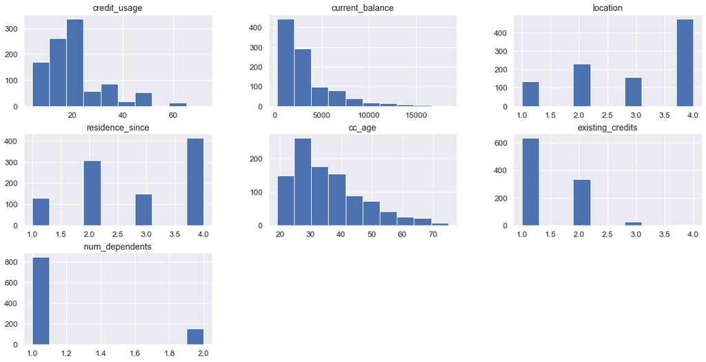

```python
#Histogram of quantitative variables
data.hist(figsize=(20,10))
plt.show()
```

###### Categorical values vs. 'class'

[figure not shown]

```python
#class vs. housing
sns.set(rc = {'figure.figsize':(15,8)})
sns.set(font_scale = 1.2)
sns.countplot(df["housing"],hue="class",data=df,palette="Accent")
plt.title("Class vs. Housing",fontsize=15,color="Black")
plt.show()
```

```python
Observations: Legitimate account holders are more likely to own housing.
    Housing status is a good predictor of the outcome variable.
```

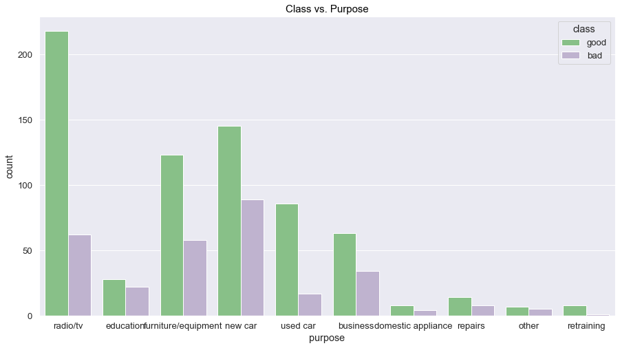

```python
#class vs. purpose
sns.set(rc = {'figure.figsize':(15,8)})
sns.set(font_scale = 1.2)
sns.countplot(data["purpose"],hue="class",data=df,palette="Accent")
plt.title("Class vs. Purpose",fontsize=15,color="Black")
plt.show()
```

Observations: Purpose might not be a good predictor of the outcome due to variability though there is noticably alot of legitimate account holders that purchase radio/tv's.

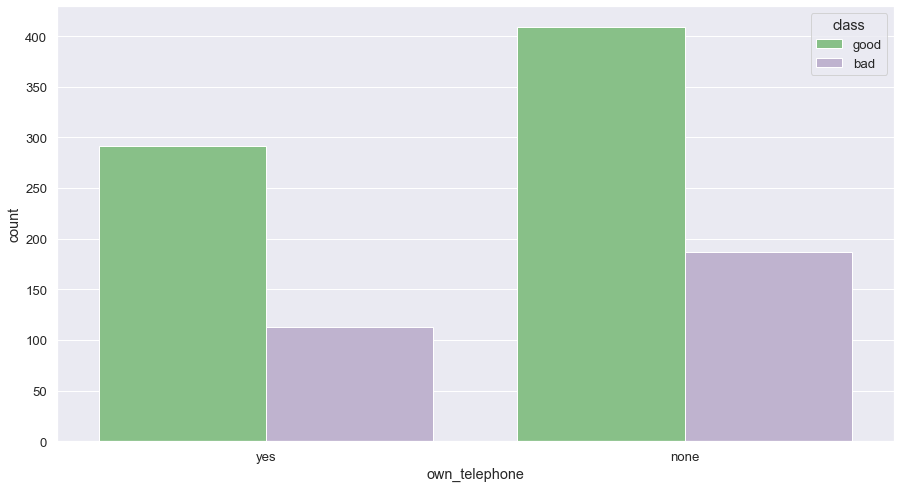

```python
#Class vs. own_telephone
#plt.figure(figsize=(15,8))
sns.set(rc = {'figure.figsize':(15,8)})
sns.set(font_scale = 1.2)
sns.countplot(data["own_telephone"],hue="class",data=df,palette="Accent")
plt.show()
```

own_telephone may not be a good predictor of the outcome due to very little variability.

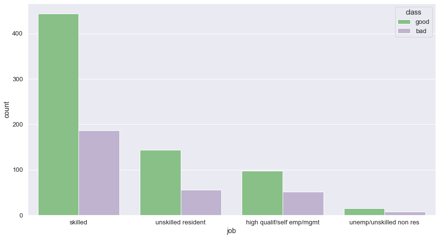

```python
#class vs. job
sns.set(rc = {'figure.figsize':(15,8)})
sns.set(font_scale = 1.2)
sns.countplot(data["job"],hue="class",data=df,palette="Accent")
plt.show()
```

Job may be a good predictor of the outcome because legitimate account holders are usually skilled workers.

# Step 4: Data Preparation for the classification models

The categorical variables "employment", "overdraft", and "Average Credit Balance" all have greater or less than signs that can cause errors in our code , I decided to have them converted above into strings for better interpretation for the models to be developed.

```python
# Removing odd characters and changing certain categorical variables to strings
data['employment']=np.where(data['employment'] =='>=7', 'greater_than_seven', data['employment'])
data['employment']=np.where(data['employment'] =='1<=X<4', 'Between_one_and_four', data['employment'])
data['employment']=np.where(data['employment'] =='4<=X<7', 'Between_four_and_seven', data['employment'])
data['employment']=np.where(data['employment'] =='<1', 'Less_than_one', data['employment'])


data['over_draft']=np.where(data['over_draft'] =='<0', 'less_than_zero', data['over_draft'])
data['over_draft']=np.where(data['over_draft'] =='0<=X<200', 'Between_zero_and_two hundred', data['over_draft'])
data['over_draft']=np.where(data['over_draft'] =='>=200', 'greater_than_two_hundred', data['over_draft'])

data['Average_Credit_Balance']=np.where(data['Average_Credit_Balance'] =='>=1000', 'greater_than_one_thousand', data['Average_Credit_Balance'])
data['Average_Credit_Balance']=np.where(data['Average_Credit_Balance'] =='<100', 'less_than_one_hundred', data['Average_Credit_Balance'])
data['Average_Credit_Balance']=np.where(data['Average_Credit_Balance'] =='500<=X<1000', 'Between_five_hundred_and_one_thousand', data['Average_Credit_Balance'])
data['Average_Credit_Balance']=np.where(data['Average_Credit_Balance'] =='100<=X<500', 'Between_one_hundred_and_five_hundred', data['Average_Credit_Balance'])
```

```python
#importing packages
import pandas as pd
import numpy as np
from sklearn import preprocessing
from sklearn.model_selection import train_test_split
sns.set(style="white")
sns.set(style="whitegrid", color_codes=True)
```

Creating the dummy variable for the categorical values below.

```python
cat_vars=['Average_Credit_Balance','over_draft','credit_history',
'purpose', 'employment','personal_status','property_magnitude',
'housing','job', 'own_telephone']
for var in cat_vars:
    cat_list='var'+'_'+var
    cat_list = pd.get_dummies(data[var], prefix=var)
    data1=data.join(cat_list)
    data=data1
cat_vars=['Average_Credit_Balance','over_draft','credit_history',
'purpose', 'employment','personal_status','property_magnitude',
'housing','job', 'own_telephone']
data_vars=data.columns.values.tolist()
to_keep=[i for i in data_vars if i not in cat_vars]
```

```python
#final columns
data_final=data[to_keep]
data_final.columns.values
```

```
array(['credit_usage', 'current_balance', 'location', 'residence_since',
       'cc_age', 'existing_credits', 'num_dependents', 'class',
       'Average_Credit_Balance_Between_five_hundred_and_one_thousand',
       'Average_Credit_Balance_Between_one_hundred_and_five_hundred',
       'Average_Credit_Balance_greater_than_one_thousand',
       'Average_Credit_Balance_less_than_one_hundred',
       'Average_Credit_Balance_no known savings',
       'over_draft_Between_zero_and_two hundred',
       'over_draft_greater_than_two_hundred', 'over_draft_less_than_zero',
       'over_draft_no checking', 'credit_history_all paid',
       'credit_history_critical/other existing credit',
       'credit_history_delayed previously',
       'credit_history_existing paid',
       'credit_history_no credits/all paid', 'purpose_business',
       'purpose_domestic appliance', 'purpose_education',
       'purpose_furniture/equipment', 'purpose_new car', 'purpose_other',
       'purpose_radio/tv', 'purpose_repairs', 'purpose_retraining',
       'purpose_used car', 'employment_Between_four_and_seven',
       'employment_Between_one_and_four', 'employment_Less_than_one',
       'employment_greater_than_seven', 'employment_unemployed',
       'personal_status_female div/dep/mar',
       'personal_status_male div/sep', 'personal_status_male mar/wid',
       'personal_status_male single', 'property_magnitude_car',
       'property_magnitude_life insurance',
       'property_magnitude_no known property',
       'property_magnitude_real estate', 'housing_for free',
       'housing_own', 'housing_rent', 'job_high qualif/self emp/mgmt',
       'job_skilled', 'job_unemp/unskilled non res',
       'job_unskilled resident', 'own_telephone_none',
       'own_telephone_yes'], dtype=object)
```

```python
#re-entering dummy variables
X = df[['Average_Credit_Balance','over_draft','credit_history',
'purpose', 'employment','personal_status','property_magnitude',
'housing','job', 'own_telephone']]

X = pd.get_dummies(data=X, drop_first=True)
```

```python
# transform all data in input and output
print('Input', X.shape)
print(X[:5, :])
print('Output', y.shape)
print(y[:5])
```

[output not shown]

There is alot of encoding being done to account for a dataset with a mix of both numerical and categorical values that can be misinterpreted in the classification models if not properly converted. I have chosen to use ordinal encoder because it is usually used for datasets with a known relationship between variable which is valid for our dataset. I also used label encoder because it is need when a target variable needs to be encoded for classification predictive modeling. (bad/fraud=0, good/legitimate=1)

```python
#importing packages
from sklearn.model_selection import train_test_split
from sklearn.preprocessing import LabelEncoder
from sklearn.preprocessing import OrdinalEncoder

#split the dataset into train and test sets
X_train, X_test, y_train, y_test = train_test_split(X, y, test_size=0.33, random_state=1)

# ordinal encode input variables
ordinal_encoder = OrdinalEncoder()
ordinal_encoder.fit(X_train)
X_train = ordinal_encoder.transform(X_train)
X_test = ordinal_encoder.transform(X_test)
# ordinal encode target variable
label_encoder = LabelEncoder()
label_encoder.fit(y_train)
y_train = label_encoder.transform(y_train)
y_test = label_encoder.transform(y_test)
```

# Step 5: Dealing with imbalanced data

The dataset is also on the smaller side with only 1000 entries and in order to draw sufficent conclusions free from potential bias on the majority class it would be suggested to increase our dataset with oversampling. Now we balance the data using the RandomOverSampler:

```python
#split the dataset into train and test and count new sets
from collections import Counter
X_train, X_test, y_train, y_test = train_test_split(X, y, test_size=0.3, random_state=100)
print(f"Training target statistics: {Counter(y_train)}")
print(f"Testing target statistics: {Counter(y_test)}")
```

[output not shown]

```python
#balancing data by oversampling the minority class
from imblearn.over_sampling import RandomOverSampler
over_sampler = RandomOverSampler(random_state=42)
X_res, y_res = over_sampler.fit_resample(X_train, y_train)
print(f"Training target statistics: {Counter(y_res)}")
print(f"Testing target statistics: {Counter(y_test)}")
```

```
Training target statistics: Counter({0: 486, 1: 486})
Testing target statistics: Counter({1: 214, 0: 86})
```

```python
#new shape of (training set)data
X_res, y_res.shape
```

```
(array([[0., 0., 1., ..., 0., 0., 1.],
        [0., 0., 1., ..., 0., 0., 1.],
        [0., 0., 1., ..., 0., 0., 1.],
        ...,
        [0., 0., 1., ..., 0., 0., 0.],
        [0., 0., 1., ..., 0., 1., 1.],
        [0., 0., 1., ..., 0., 0., 0.]]),
 (972,))
```

Now the data is balanced; I chose to over-sample only on the training data, because it can assist with making sure that none of the information in the test data is being used to create synthetic observations affecting the classification model interpretations.

# Step 6: Classification Models and Performance Metrics

```python
#Import Performance metric packages
from sklearn.metrics import confusion_matrix
from sklearn.metrics import classification_report
from sklearn.metrics import accuracy_score
from sklearn.metrics import f1_score
```

```
Accuracy of logistic regression classifier on test set: 0.74
```

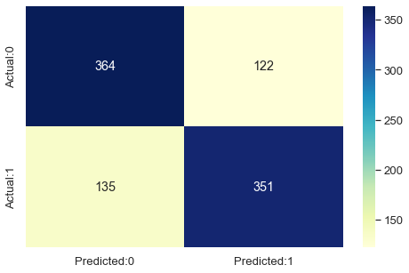

```python
#Logistic regression classification model
lr = LogisticRegression()
lr.fit(X_res, y_res)
lr_yhat = lr.predict(X_test)
# evaluate predictions
lr_pred = lr.predict(X_res)
confusion_matrix = confusion_matrix(y_res, lr_pred)
conf_matrix=pd.DataFrame(data=confusion_matrix,columns=['Predicted:0','Predicted:1'],index=['Actual:0','Actual:1'])
plt.figure(figsize = (8,5))
sns.heatmap(conf_matrix, annot=True,fmt='d',cmap="YlGnBu");
print('Accuracy of logistic regression classifier on test set: {:.2f}'.format(lr.score(X_res, y_res)))
```

```
Accuracy of Decision Tree classifier on test set: 0.71
```

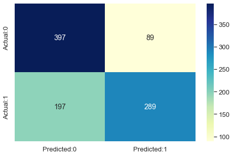

```python
#Decision Tree model
tree_model = DecisionTreeClassifier(max_depth = 4, criterion = 'entropy')
tree_model.fit(X_res, y_res)
tree_yhat = tree_model.predict(X_test)
# evaluate predictions
tree_model_pred = tree_model.predict(X_res)
print('Accuracy of Decision Tree classifier on test set: {:.2f}'.format(tree_model.score(X_res, y_res)))
confusion_matrix = confusion_matrix(y_res, tree_model_pred)
conf_matrix=pd.DataFrame(data=confusion_matrix,columns=['Predicted:0','Predicted:1'],index=['Actual:0','Actual:1'])
plt.figure(figsize = (8,5))
sns.heatmap(conf_matrix, annot=True,fmt='d',cmap="YlGnBu");
```

```
Accuracy of Support vector classifier on test set: 0.87
```

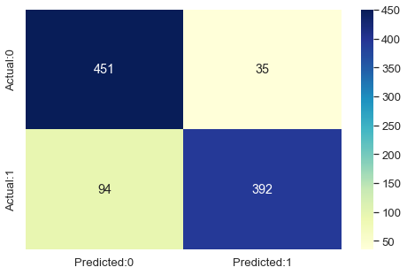

```python
#SVC classification model
svm = SVC()
svm.fit(X_res, y_res)
svm_yhat = svm.predict(X_test)
# evaluate predictions
svm_pred = svm.predict(X_res)
confusion_matrix = confusion_matrix(y_res, svm_pred)
conf_matrix=pd.DataFrame(data=confusion_matrix,columns=['Predicted:0','Predicted:1'],index=['Actual:0','Actual:1'])
plt.figure(figsize = (8,5))
sns.heatmap(conf_matrix, annot=True,fmt='d',cmap="YlGnBu");
print('Accuracy of Support vector classifier on test set: {:.2f}'.format(svm.score(X_res, y_res)))
```

```
Accuracy of RandomForest classifier on test set: 0.74
```

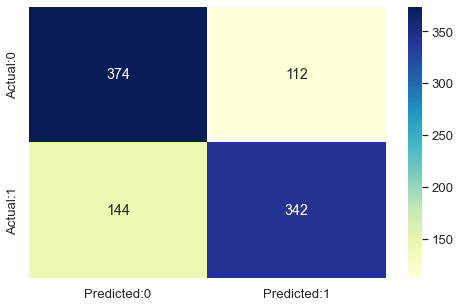

```python
#Random Forest tree classification model
rf = RandomForestClassifier(max_depth = 4)
rf.fit(X_res, y_res)
rf_yhat = rf.predict(X_test)
# evaluate predictions
rf_pred = rf.predict(X_res)
print('Accuracy of RandomForest classifier on test set: {:.2f}'.format(rf.score(X_res, y_res)))
confusion_matrix = confusion_matrix(y_res, rf_pred)
conf_matrix=pd.DataFrame(data=confusion_matrix,columns=['Predicted:0','Predicted:1'],index=['Actual:0','Actual:1'])
plt.figure(figsize = (8,5))
sns.heatmap(conf_matrix, annot=True,fmt='d',cmap="YlGnBu");
```

```
Accuracy of knn classifier on test set: 0.83
```

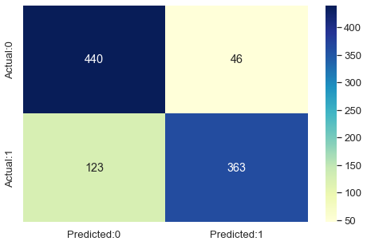

```python
#Knn classification model
n = 5
knn = KNeighborsClassifier(n_neighbors = n)
knn.fit(X_res, y_res)
knn_yhat = knn.predict(X_test)
#evaluate predictions
knn_pred = knn.predict(X_res)
print('Accuracy of knn classifier on test set: {:.2f}'.format(knn.score(X_res, y_res)))
confusion_matrix = confusion_matrix(y_res, knn_pred)
conf_matrix=pd.DataFrame(data=confusion_matrix,columns=['Predicted:0','Predicted:1'],index=['Actual:0','Actual:1'])
plt.figure(figsize = (8,5))
sns.heatmap(conf_matrix, annot=True,fmt='d',cmap="YlGnBu");
```